# Bayesian GLM Part4

```r
loyn_brm3 |> get_variables()
```

```
 [1] "b_Intercept"     "b_scalelogDIST"  "b_scalelogLDIST" "b_scalelogAREA"
 [5] "b_fGRAZE2"       "b_fGRAZE3"       "b_fGRAZE4"       "b_fGRAZE5"
 [9] "b_scaleALT"      "b_scaleYR.ISOL"  "sigma"           "Intercept"
[13] "prior_Intercept" "prior_b"         "prior_sigma"     "lprior"
[17] "lp__"            "accept_stat__"   "stepsize__"      "treedepth__"
[21] "n_leapfrog__"    "divergent__"     "energy__"
```

```r
loyn_draw <- loyn_brm3 |> gather_draws(`^b_.*`, regex = TRUE)
loyn_draw
```

```
# A tibble: 15,000 × 5
# Groups:   .variable [10]
   .chain .iteration .draw .variable   .value
    <int>      <int> <int> <chr>        <dbl>
 1      1          1     1 b_Intercept   2.99
 2      1          2     2 b_Intercept   3.13
 3      1          3     3 b_Intercept   3.08
 4      1          4     4 b_Intercept   3.08
 5      1          5     5 b_Intercept   2.99
 6      1          6     6 b_Intercept   3.14
 7      1          7     7 b_Intercept   3.15
 8      1          8     8 b_Intercept   3.12
 9      1          9     9 b_Intercept   3.10
10      1         10    10 b_Intercept   3.03
# ℹ 14,990 more rows
```

**bayesplot**

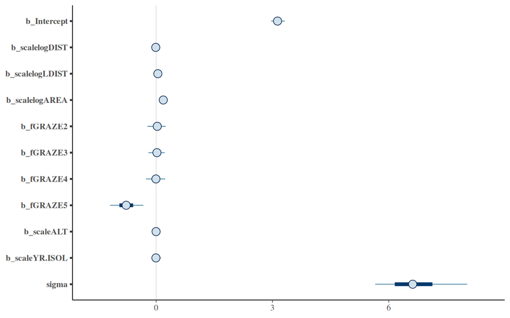

```r
loyn_brm3 |> mcmc_plot(type = "intervals")
```

**half-eye (ggdist)**

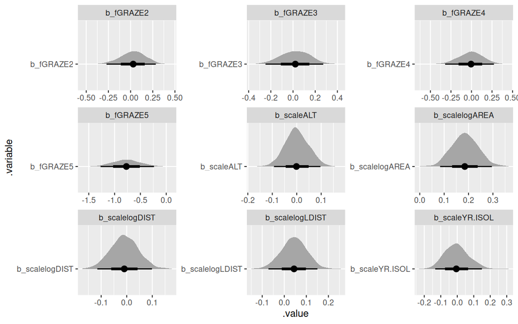

```r
loyn_brm3 |>
  gather_draws(`^b_.*`, regex = TRUE) |>
  filter(.variable != "b_Intercept") |>
  ggplot() +
  stat_halfeye(aes(x = .value, y = .variable)) +
  facet_wrap(~.variable, scales = "free")
```

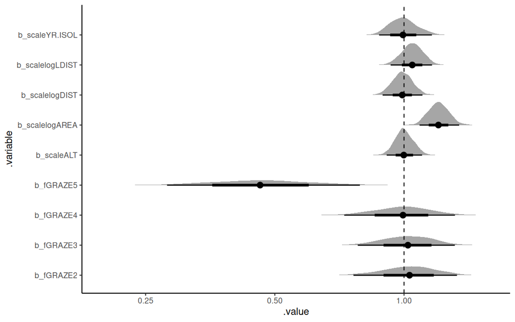

```r
loyn_brm3 |>
  gather_draws(`^b_.*`, regex = TRUE) |>
  mutate(.value = exp(.value)) |>
  filter(.variable != "b_Intercept") |>
  ggplot() +
  stat_halfeye(aes(x = .value, y = .variable)) +
  geom_vline(xintercept = 1, linetype = "dashed") +
  scale_x_continuous(trans = scales::log2_trans()) +
  theme_classic()
```

**density ridges (ggridges)**

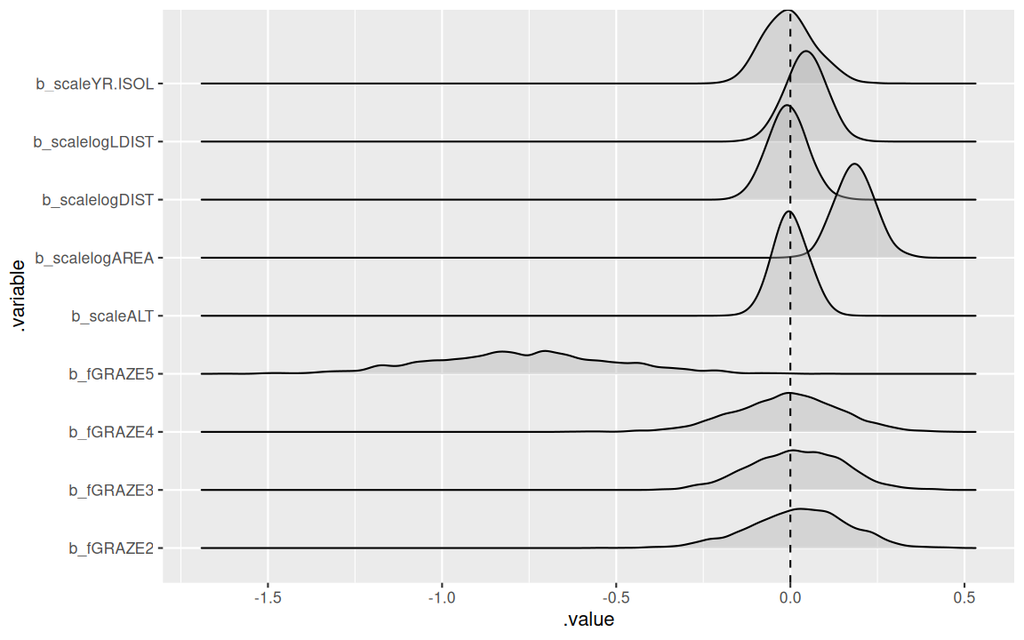

```r
loyn_brm3 |>
  gather_draws(`^b_.*`, regex = TRUE) |>
  filter(.variable != "b_Intercept") |>
  ggplot() +
  geom_density_ridges(aes(x = .value, y = .variable), alpha = 0.4) +
  geom_vline(xintercept = 0, linetype = "dashed")
```

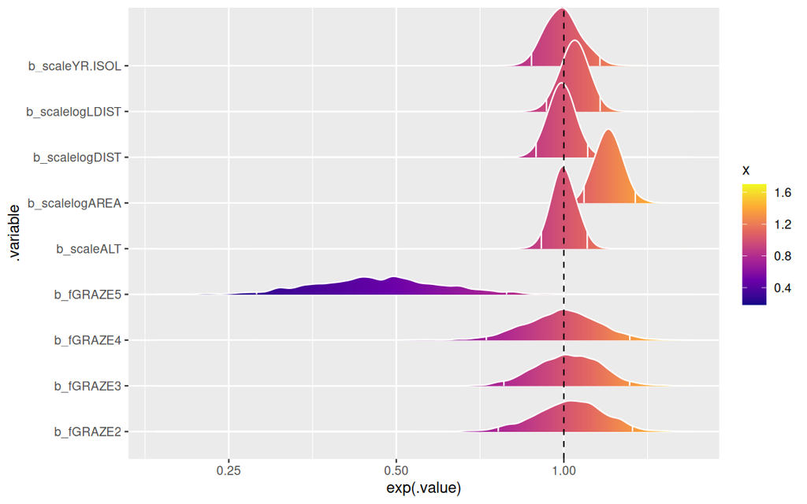

```r
## Or on a fractional scale
loyn_brm3 |>
  gather_draws(`^b_.*`, regex = TRUE) |>
  filter(.variable != "b_Intercept") |>
  ggplot() +
  geom_density_ridges_gradient(
    aes(
      x = exp(.value),
      y = .variable,
      fill = stat(x)
    ),
    alpha = 0.4, colour = "white",
    quantile_lines = TRUE,
    quantiles = c(0.025, 0.975)
  ) +
  geom_vline(xintercept = 1, linetype = "dashed") +
  scale_x_continuous(trans = scales::log2_trans()) +
  scale_fill_viridis_c(option = "C")
```

**spread_draws**

```r
loyn_brm3 |> spread_draws(`^b_.*`, regex = TRUE)
```

```
# A tibble: 1,500 × 13
   .chain .iteration .draw b_Intercept b_scalelogDIST b_scalelogLDIST
    <int>      <int> <int>       <dbl>          <dbl>           <dbl>
 1      1          1     1        2.99         0.0124         0.0296
 2      1          2     2        3.13         0.0583        -0.0853
 3      1          3     3        3.08         0.0319         0.0303
 4      1          4     4        3.08         0.0230         0.151
 5      1          5     5        2.99        -0.0788         0.00273
 6      1          6     6        3.14         0.0138        -0.00286
 7      1          7     7        3.15        -0.0379         0.164
 8      1          8     8        3.12         0.0163        -0.0124
 9      1          9     9        3.10        -0.0247         0.0949
10      1         10    10        3.03         0.0639         0.0737
# ℹ 1,490 more rows
# ℹ 7 more variables: b_scalelogAREA <dbl>, b_fGRAZE2 <dbl>, b_fGRAZE3 <dbl>,
#   b_fGRAZE4 <dbl>, b_fGRAZE5 <dbl>, b_scaleALT <dbl>, b_scaleYR.ISOL <dbl>
```

**posterior_samples**

```r
loyn_brm3 |>
  posterior_samples() |>
  as_tibble()
```

```
# A tibble: 1,500 × 17
   b_Intercept b_scalelogDIST b_scalelogLDIST b_scalelogAREA b_fGRAZE2 b_fGRAZE3
         <dbl>          <dbl>           <dbl>          <dbl>     <dbl>     <dbl>
 1        2.99         0.0124         0.0296          0.212     0.105    0.108
 2        3.13         0.0583        -0.0853          0.209    -0.0229  -0.0385
 3        3.08         0.0319         0.0303          0.248    -0.0820   0.134
 4        3.08         0.0230         0.151           0.162     0.200   -0.0364
 5        2.99        -0.0788         0.00273         0.289    -0.238    0.0645
 6        3.14         0.0138        -0.00286         0.183     0.0537  -0.00244
 7        3.15        -0.0379         0.164           0.203    -0.163   -0.00459
 8        3.12         0.0163        -0.0124          0.235     0.149    0.0183
 9        3.10        -0.0247         0.0949          0.227     0.0283   0.134
10        3.03         0.0639         0.0737          0.0906    0.0494   0.146
# ℹ 1,490 more rows
# ℹ 11 more variables: b_fGRAZE4 <dbl>, b_fGRAZE5 <dbl>, b_scaleALT <dbl>,
#   b_scaleYR.ISOL <dbl>, sigma <dbl>, Intercept <dbl>, prior_Intercept <dbl>,
#   prior_b <dbl>, prior_sigma <dbl>, lprior <dbl>, lp__ <dbl>
```

**\(R^2\)**

```r
loyn_brm3 |>
  bayes_R2(summary = FALSE) |>
  median_hdci()
```

```
          y      ymin      ymax .width .point .interval
1 0.6145945 0.4972832 0.7017797   0.95 median      hdci
```

**ROPE**

Region of Practical Equivalence

For standardised parameter (negligible effect)

```r
0.1 * sd(log(loyn$ABUND))
```

```
[1] 0.09024351
```

```r
loyn_brm3 |> bayestestR::rope_range()
```

```
[1] -0.01  0.01
```

```r
loyn_brm3 |> bayestestR::rope(range = c(-0.09, 0.09))
```

```
# Proportion of samples inside the ROPE [-0.09, 0.09]:

Parameter     | Inside ROPE
---------------------------
Intercept     |      0.00 %
scalelogDIST  |     94.73 %
scalelogLDIST |     81.04 %
scalelogAREA  |      0.70 %
fGRAZE2       |     48.31 %
fGRAZE3       |     51.05 %
fGRAZE4       |     48.74 %
fGRAZE5       |      0.00 %
scaleALT      |     98.17 %
scaleYR.ISOL  |     81.74 %
```

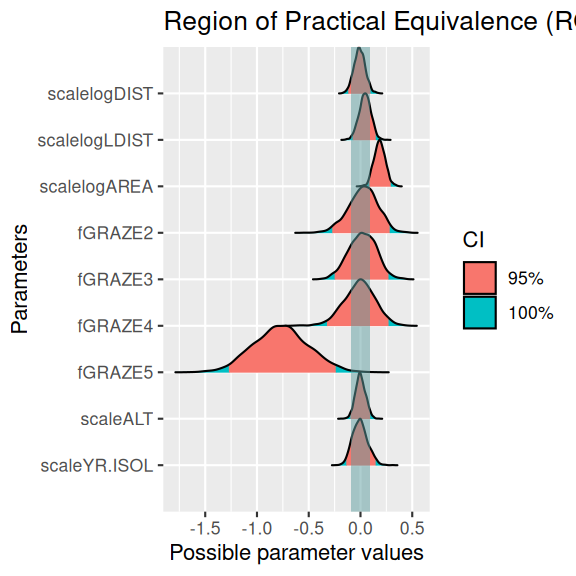

```r
loyn_brm3 |>
  bayestestR::rope(range = c(-0.09, 0.09)) |>
  plot(data = loyn_brm3)
```

# 10 Further analyses

**Model selection**

**rstanarm**

```r
loyn_rstanarm4a <- update(loyn_rstanarm3, . ~ scale(log(DIST)) * scale(log(LDIST)),
  diagnostic_file = file.path(tempdir(), "dfa.csv")
)
loyn_rstanarm4b <- update(loyn_rstanarm3, . ~ scale(log(AREA)) * fGRAZE,
  diagnostic_file = file.path(tempdir(), "dfb.csv")
)
loyn_rstanarm4c <- update(loyn_rstanarm3, . ~ scale(log(AREA)) * fGRAZE * scale(YR.ISOL),
  diagnostic_file = file.path(tempdir(), "dfc.csv")
)
loyn_rstanarm4d <- update(loyn_rstanarm3, . ~ scale(ALT),
  diagnostic_file = file.path(tempdir(), "dfd.csv")
)
loyn_rstanarm4e <- update(loyn_rstanarm3, . ~ 1,
  diagnostic_file = file.path(tempdir(), "dfe.csv")
)
loo_compare(
  loo(loyn_rstanarm4a),
  loo(loyn_rstanarm4e)
)
```

```
                elpd_diff se_diff
loyn_rstanarm4e  0.0       0.0
loyn_rstanarm4a -2.4       1.5
```

```r
loo_compare(
  loo(loyn_rstanarm4b),
  loo(loyn_rstanarm4e)
)
```

```
                elpd_diff se_diff
loyn_rstanarm4b   0.0       0.0
loyn_rstanarm4e -30.4       7.2
```

```r
loo_compare(
  loo(loyn_rstanarm4c),
  loo(loyn_rstanarm4e)
)
```

```
                elpd_diff se_diff
loyn_rstanarm4c   0.0       0.0
loyn_rstanarm4e -22.0       6.8
```

```r
loo_compare(
  loo(loyn_rstanarm4d),
  loo(loyn_rstanarm4e)
)
```

```
                elpd_diff se_diff
loyn_rstanarm4d  0.0       0.0
loyn_rstanarm4e -3.6       2.3
```

```r
bayes_factor(
  bridge_sampler(loyn_rstanarm4a),
  bridge_sampler(loyn_rstanarm4e)
)
```

```
Iteration: 1
Iteration: 2
Iteration: 3
Iteration: 4
Iteration: 5
Iteration: 6
Iteration: 1
Iteration: 2
Iteration: 3
Iteration: 4
Iteration: 5
```

```
Estimated Bayes factor in favor of x1 over x2: 0.00138
```

```r
bayes_factor(
  bridge_sampler(loyn_rstanarm4b),
  bridge_sampler(loyn_rstanarm4e)
)
```

```
Iteration: 1
Iteration: 2
Iteration: 3
Iteration: 4
Iteration: 5
Iteration: 6
Iteration: 1
Iteration: 2
Iteration: 3
Iteration: 4
Iteration: 5
```

```
Estimated Bayes factor in favor of x1 over x2: 1032891552.95408
```

```r
bayes_factor(
  bridge_sampler(loyn_rstanarm4c),
  bridge_sampler(loyn_rstanarm4e)
)
```

```
Iteration: 1
Iteration: 2
Iteration: 3
Iteration: 4
Iteration: 5
Iteration: 1
Iteration: 2
Iteration: 3
Iteration: 4
```

```
Estimated Bayes factor in favor of x1 over x2: 7541.08718
```

```r
bayes_factor(
  bridge_sampler(loyn_rstanarm4d),
  bridge_sampler(loyn_rstanarm4e)
)
```

```
Iteration: 1
Iteration: 2
Iteration: 3
Iteration: 4
Iteration: 5
Iteration: 6
Iteration: 1
Iteration: 2
Iteration: 3
Iteration: 4
```

```
Estimated Bayes factor in favor of x1 over x2: 5.03167
```

**brm**

```r
loyn_brm4a <- update(loyn_brm3, . ~ scale(log(DIST)) * scale(log(LDIST)),
  save_pars = save_pars(all = TRUE), refresh = 0
)
loyn_brm4b <- update(loyn_brm3, . ~ scale(log(AREA)) * fGRAZE,
  save_pars = save_pars(all = TRUE), refresh = 0
)
loyn_brm4c <- update(loyn_brm3, . ~ scale(log(AREA)) * fGRAZE * scale(YR.ISOL),
  save_pars = save_pars(all = TRUE), refresh = 0
)
loyn_brm4d <- update(loyn_brm3, . ~ scale(ALT),
  save_pars = save_pars(all = TRUE), refresh = 0
)
loyn_brm4e <- update(loyn_brm3, . ~ 1,
  save_pars = save_pars(all = TRUE), refresh = 0
)
```

```
The desired updates require recompiling the model
```

```r
waic(loyn_brm4a)
```

```
Computed from 1500 by 56 log-likelihood matrix.

          Estimate  SE
elpd_waic   -217.0 4.5
p_waic         3.9 0.8
waic         434.1 9.0

2 (3.6%) p_waic estimates greater than 0.4. We recommend trying loo instead.
```

```r
loo(loyn_brm4a)
```

```
Computed from 1500 by 56 log-likelihood matrix.

         Estimate  SE
elpd_loo   -217.2 4.5
p_loo         4.1 0.9
looic       434.4 9.0
------
MCSE of elpd_loo is NA.
MCSE and ESS estimates assume MCMC draws (r_eff in [0.8, 1.2]).

Pareto k diagnostic values:
                          Count Pct.    Min. ESS
(-Inf, 0.69]   (good)     55    98.2%   525
   (0.69, 1]   (bad)       1     1.8%   <NA>
    (1, Inf)   (very bad)  0     0.0%   <NA>
See help('pareto-k-diagnostic') for details.
```

```r
loo(loyn_brm4e)
```

```
Computed from 1500 by 56 log-likelihood matrix.

         Estimate  SE
elpd_loo   -215.2 4.5
p_loo         1.2 0.2
looic       430.4 9.1
------
MCSE of elpd_loo is 0.0.
MCSE and ESS estimates assume MCMC draws (r_eff in [0.9, 1.0]).

All Pareto k estimates are good (k < 0.69).
See help('pareto-k-diagnostic') for details.
```

```r
loo_compare(
  loo(loyn_brm4a),
  loo(loyn_brm4e)
)
```

```
           elpd_diff se_diff
loyn_brm4e  0.0       0.0
loyn_brm4a -2.0       1.2
```

```r
loo_compare(
  loo(loyn_brm4b),
  loo(loyn_brm4e)
)
```

```
           elpd_diff se_diff
loyn_brm4b   0.0       0.0
loyn_brm4e -29.6       7.1
```

```r
loo_compare(
  loo(loyn_brm4b, moment_match = TRUE),
  loo(loyn_brm4e)
)
```

```
           elpd_diff se_diff
loyn_brm4b   0.0       0.0
loyn_brm4e -29.6       7.1
```

```r
loo_compare(
  loo(loyn_brm4c, moment_match = TRUE),
  loo(loyn_brm4e)
)
```

```
           elpd_diff se_diff
loyn_brm4c   0.0       0.0
loyn_brm4e -19.8       6.8
```

```r
loo_compare(
  loo(loyn_brm4d),
  loo(loyn_brm4e)
)
```

```
           elpd_diff se_diff
loyn_brm4d  0.0       0.0
loyn_brm4e -3.5       2.0
```

An alternative is to compute Bayes factors based on **bridge sampling**. Note, this process usually requires far greater number of posterior samples (10x) in order to be stable. It is also advisable to run this multiple times to ensure stability.

It calculates the marginal likelihood of one model in favour of another. The larger the value, the more evidence there is of one model over the other.

```r
bayes_factor(
  loyn_brm4a,
  loyn_brm4e
)
```

```
Iteration: 1
Iteration: 2
Iteration: 3
Iteration: 4
Iteration: 5
Iteration: 6
Iteration: 1
Iteration: 2
Iteration: 3
Iteration: 4
Iteration: 5
```

```
Estimated Bayes factor in favor of loyn_brm4a over loyn_brm4e: 0.00008
```

```r
# OR
bayes_factor(
  loyn_brm4e,
  loyn_brm4a
)
```

```
Iteration: 1
Iteration: 2
Iteration: 3
Iteration: 4
Iteration: 5
Iteration: 1
Iteration: 2
Iteration: 3
Iteration: 4
Iteration: 5
Iteration: 6
```

```
Estimated Bayes factor in favor of loyn_brm4e over loyn_brm4a: 12154.10618
```

```r
bayes_factor(
  loyn_brm4b,
  loyn_brm4e
)
```

```
Iteration: 1
Iteration: 2
Iteration: 3
Iteration: 4
Iteration: 5
Iteration: 6
Iteration: 1
Iteration: 2
Iteration: 3
Iteration: 4
```

```
Estimated Bayes factor in favor of loyn_brm4b over loyn_brm4e: 4742.64089
```

```r
# OR
bayes_factor(
  loyn_brm4e,
  loyn_brm4b
)
```

```
Iteration: 1
Iteration: 2
Iteration: 3
Iteration: 4
Iteration: 1
Iteration: 2
Iteration: 3
Iteration: 4
Iteration: 5
Iteration: 6
Iteration: 7
```

```
Estimated Bayes factor in favor of loyn_brm4e over loyn_brm4b: 0.00021
```

```r
bayes_factor(
  loyn_brm4c,
  loyn_brm4e
)
```

```
Iteration: 1
Iteration: 2
Iteration: 3
Iteration: 4
Iteration: 5
Iteration: 6
Iteration: 7
Iteration: 1
Iteration: 2
Iteration: 3
Iteration: 4
Iteration: 5
```

```
Estimated Bayes factor in favor of loyn_brm4c over loyn_brm4e: 0.00005
```

```r
# OR
bayes_factor(
  loyn_brm4e,
  loyn_brm4c
)
```

```
Iteration: 1
Iteration: 2
Iteration: 3
Iteration: 4
Iteration: 5
Iteration: 1
Iteration: 2
Iteration: 3
Iteration: 4
Iteration: 5
Iteration: 6
```

```
Estimated Bayes factor in favor of loyn_brm4e over loyn_brm4c: 19966.81767
```

```r
bayes_factor(
  loyn_brm4d,
  loyn_brm4e
)
```

```
Iteration: 1
Iteration: 2
Iteration: 3
Iteration: 4
Iteration: 5
Iteration: 1
Iteration: 2
Iteration: 3
Iteration: 4
Iteration: 5
```

```
Estimated Bayes factor in favor of loyn_brm4d over loyn_brm4e: 1.29520
```